# BNC5 Metabolomics Analysis — Pellet Positive Mode

Response of Bacillus amyloliquefaciens BNC5 to Ralstonia solanacearum Whole Cells

Augustine Onuh, PhD | Chulalongkorn University

2026-08-23

## 1 Executive Summary

This report presents untargeted LC-MS metabolomics analysis of *Bacillus amyloliquefaciens* BNC5 pellet extracts comparing three conditions: BNC5 alone, BNC5 co-cultured with *Ralstonia solanacearum* whole cells (BNC5RSw), and RSw alone (dead cell background control).

**Key findings:**

- **7744** features showed significant variation across groups (ANOVA, BH-adjusted p < 0.05)
- **2847** features were elevated in BNC5RSw vs BNC5 (log2FC > 0.58, p_BH < 0.05)
- After removing **1314** RSw background features, **1533** true BNC5 response features were identified
- **857** features showed greater than 10-fold elevation in BNC5RSw vs BNC5
- **1559** features were significantly reduced in BNC5RSw compared to BNC5 alone

## 2 Study Design

Table 1: Experimental design and sample overview

| Condition | Description | Replicates | Role |
| --- | --- | --- | --- |
| BNC5 | B. amyloliquefaciens BNC5 alone — negative control | 6 (3 x Lot1 + 3 x Lot2) | Baseline BNC5 metabolome |
| BNC5RSw | BNC5 co-cultured with R. solanacearum whole cells — treatment | 6 (3 x Lot1 + 3 x Lot2) | RSw-induced metabolic response |
| RSw | R. solanacearum whole cells alone — background control | 6 (3 x Lot1 + 3 x Lot2) | Background subtraction control |

**Instrument:** HPLC-QTOF ESI-MS (positive ionisation mode) **Sample type:** Bacterial cell pellets **Biological lots:** 2 independent preparations per condition **Total samples analysed:** 18

## 3 Data Processing

### 3.1 XCMS Peak Detection

Raw mzXML files were processed using XCMS (v4.10.1):

- Peak detection: CentWave algorithm
- Retention time correction: LOESS smoothing, span = 0.6, 2 rounds
- Peak grouping: density method, bandwidth = 10
- Missing peak filling: fillPeaks()
- Adduct and isotope annotation: CAMERA (positive mode)
- **Total features detected: 11724**

### 3.2 Preprocessing Pipeline

Table 2: Step-by-step preprocessing summary

| Step | Result |
| --- | --- |
| Raw XCMS features | 11724 features detected |
| Zeros converted to NA | 5991 zeros replaced with NA |
| 50% per-group presence filter | 11724 features retained — 0 removed |
| Half-minimum imputation | All missing values replaced — 0 NAs remaining |
| TIC normalisation | All 18 samples normalised to equal total ion count |
| Log2 transformation | Log-normal distribution corrected |
| Autoscaling (z-score per feature) | Mean = 0, SD = 1 per feature across samples |

## 4 Quality Control

### 4.1 Lot Effect Assessment

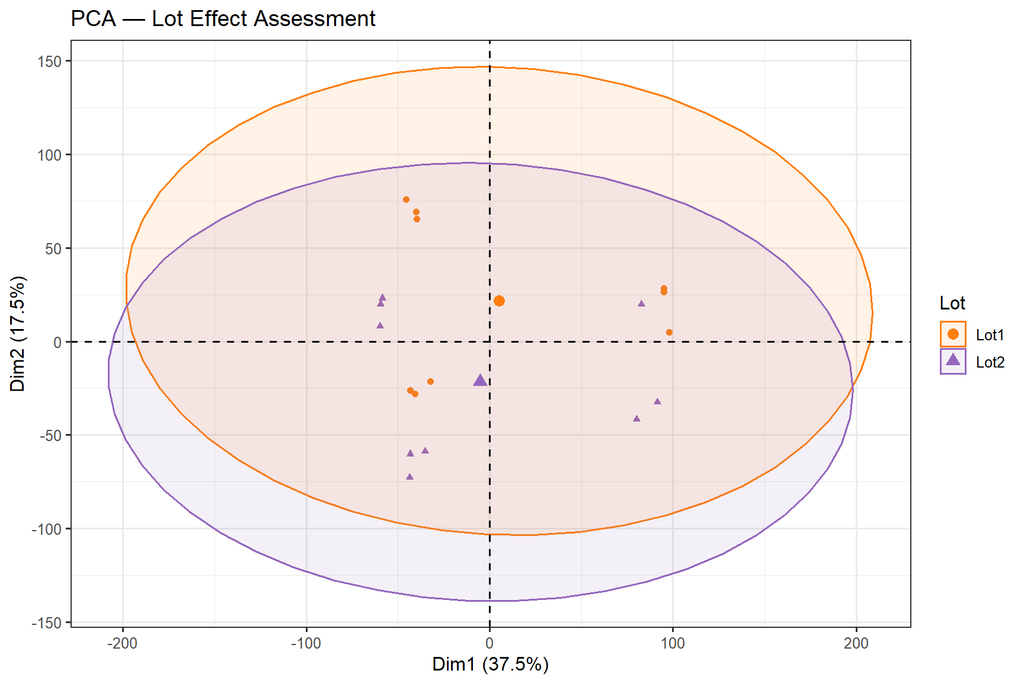

Figure 1: PCA coloured by biological lot. Complete overlap between Lot1 and Lot2 confirms no significant technical batch effect between the two independent biological replicates.

Lot1 and Lot2 samples overlapped completely in PCA space confirming no significant technical effect between the two independent biological lots. Lot was therefore not included as a covariate in statistical models.

### 4.2 Biological Group Separation

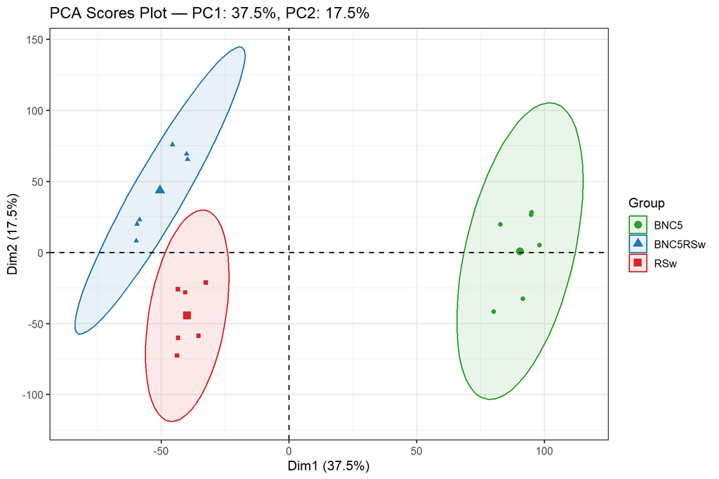

## 5 Statistical Analysis

### 5.1 ANOVA Results

**7744** of 11724 features showed significant variation across the three groups after Benjamini-Hochberg correction (p < 0.05).

Table 3: Top 15 features by ANOVA significance (BH-corrected)

| Feature | Raw p-value | BH-adjusted p | Significant |
| --- | --- | --- | --- |
| M209.1854T2459.65 | 2.96e-24 | 3.47e-20 | TRUE |
| M244.2218T2458.95 | 3.78e-23 | 2.21e-19 | TRUE |
| M605.5372T2577.56 | 9.90e-23 | 3.16e-19 | TRUE |
| M1486.0275T2464.02 | 1.08e-22 | 3.16e-19 | TRUE |
| M736.5008T2412.35 | 5.95e-22 | 1.40e-18 | TRUE |
| M688.4819T2453.61 | 2.07e-21 | 3.62e-18 | TRUE |
| M1449.0594T2560.52 | 2.16e-21 | 3.62e-18 | TRUE |
| M474.2553T1781.54 | 2.80e-21 | 4.10e-18 | TRUE |
| M689.4844T2453.93 | 6.85e-21 | 8.92e-18 | TRUE |
| M210.1887T2459.57 | 1.18e-20 | 1.38e-17 | TRUE |
| M737.5029T2412.39 | 1.84e-20 | 1.96e-17 | TRUE |
| M714.4957T2483.19 | 5.11e-20 | 5.00e-17 | TRUE |
| M226.2119T2458.34 | 6.47e-20 | 5.84e-17 | TRUE |
| M371.2206T2802.03 | 9.04e-20 | 7.57e-17 | TRUE |
| M1145.9098T2565.67 | 9.99e-20 | 7.81e-17 | TRUE |

### 5.2 RSw Background Filter

To identify metabolites specifically produced by BNC5 in response to RSw, a three-step filter was applied:

| Filter Step | Count |
| --- | --- |
| Features elevated in BNC5RSw vs BNC5 (log2FC > 0.58, p_BH < 0.05) | 2847 |
| Removed — also elevated in RSw background | 1314 |
| **True BNC5 response features** | **1533** |
| Features reduced in BNC5RSw vs BNC5 | 1559 |

### 5.3 Volcano Plot

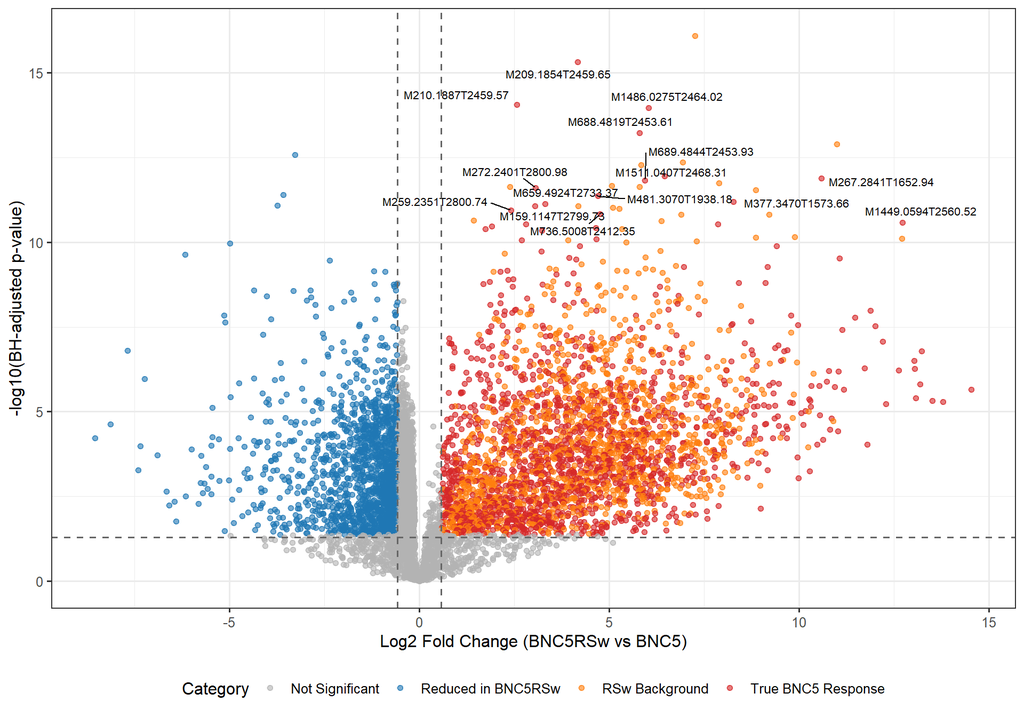

Figure 3: Volcano plot of BNC5RSw vs BNC5. Red = true BNC5 response features. Orange = RSw background features removed by filter. Blue = features reduced in BNC5RSw. Grey = not significant.

## 6 Multivariate Analysis — PLS-DA

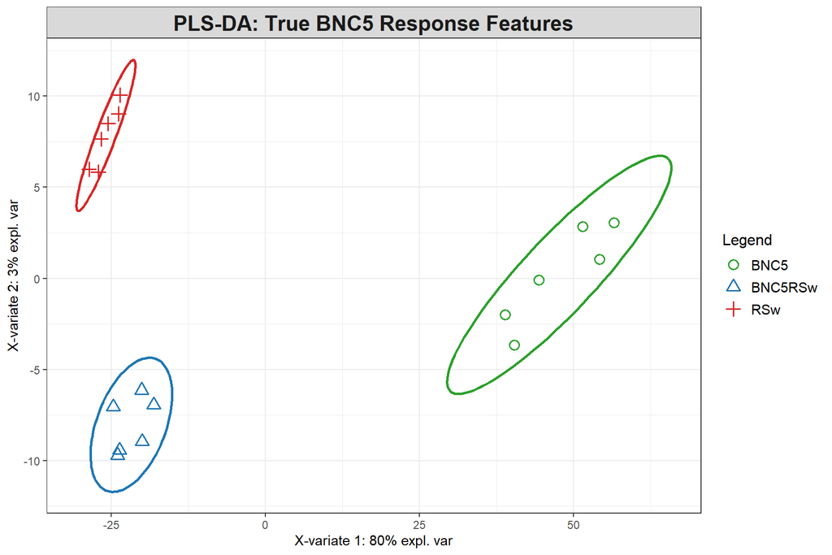

Figure 4: PLS-DA scores plot using 1,533 true BNC5 response features. Complete separation of all three groups confirms biological specificity of the identified response metabolome.

## 7 Top BNC5 Response Features

Table 4: Top 20 true BNC5 response features ranked by VIP score

| Feature | m/z | RT (min) | Log2FC | Fold Change | p_BH | VIP Score |
| --- | --- | --- | --- | --- | --- | --- |
| M209.1854T2459.65 | 209.1854 | 40.99 | 4.173 | 18.04 | 1.91e-12 | 1.126 |
| M210.1887T2459.57 | 210.1887 | 40.99 | 2.572 | 5.94 | 2.13e-11 | 1.126 |
| M688.4819T2453.61 | 688.4819 | 40.89 | 5.806 | 55.96 | 9.48e-11 | 1.126 |
| M689.4844T2453.93 | 689.4844 | 40.90 | 5.947 | 61.68 | 9.89e-10 | 1.126 |
| M244.2218T2458.95 | 244.2218 | 40.98 | 4.669 | 25.44 | 1.39e-08 | 1.126 |
| M605.5372T2577.56 | 605.5372 | 42.96 | 3.212 | 9.27 | 2.71e-08 | 1.126 |
| M1449.0594T2560.52 | 1449.0594 | 42.68 | 12.727 | 6780.91 | 6.00e-09 | 1.125 |
| M226.2119T2458.34 | 226.2119 | 40.97 | 2.322 | 5.00 | 7.56e-08 | 1.125 |
| M578.4196T2801.03 | 578.4196 | 46.68 | 8.412 | 340.59 | 1.38e-07 | 1.125 |
| M371.2206T2802.03 | 371.2206 | 46.70 | 9.122 | 557.13 | 1.40e-07 | 1.125 |
| M714.4957T2483.19 | 714.4957 | 41.39 | 3.523 | 11.50 | 3.04e-07 | 1.125 |
| M702.4961T2487.28 | 702.4961 | 41.45 | 4.061 | 16.69 | 3.32e-07 | 1.125 |
| M537.3803T2801.03 | 537.3803 | 46.68 | 7.354 | 163.59 | 6.01e-07 | 1.125 |
| M1486.0275T2464.02 | 1486.0275 | 41.07 | 6.038 | 65.71 | 2.13e-11 | 1.124 |
| M1511.0407T2468.31 | 1511.0407 | 41.14 | 6.466 | 88.39 | 8.92e-10 | 1.124 |
| M267.2841T1652.94 | 267.2841 | 27.55 | 10.591 | 1542.72 | 9.31e-10 | 1.124 |
| M481.3070T1938.18 | 481.3070 | 32.30 | 4.704 | 26.07 | 1.70e-09 | 1.124 |
| M736.5008T2412.35 | 736.5008 | 40.21 | 4.758 | 27.06 | 3.85e-09 | 1.124 |
| M1145.9098T2565.67 | 1145.9098 | 42.76 | 9.411 | 680.64 | 1.94e-08 | 1.124 |
| M759.5611T2610.96 | 759.5611 | 43.52 | 6.334 | 80.70 | 1.56e-07 | 1.124 |

## 8 Conclusions

Untargeted positive-mode LC-MS metabolomics of *B. amyloliquefaciens* BNC5 pellet extracts identified **1533** features specifically elevated in BNC5 upon exposure to *R. solanacearum* whole cells, after rigorous removal of RSw background metabolites (n = 1314).

A further **1559** features were significantly reduced in BNC5RSw compared to BNC5 alone, indicating active metabolic reprogramming in response to pathogen challenge — consistent with resource reallocation toward defensive compound biosynthesis.

**Recommended next steps:**

1. Putative annotation of the 1533 true BNC5 response features using accurate mass database searching (HMDB, METLIN, LipidMaps) and MS/MS fragmentation confirmation
2. Supernatant fraction analysis using the identical pipeline to characterise secreted metabolites
3. Negative ionisation mode analysis for complementary lipid and organic acid coverage

*Analysis performed by Augustine Onuh, PhD*  
*Department of Chemistry, Chulalongkorn University, Bangkok, Thailand*  
*Generated: 2026-08-23 | R 4.6.0 | xcms v4.10.1*